# Workflow Confidence Interval Estimation

Jeremiah MF Kelly

15/02/2021

The parameters are first estimated using a gradient descent method (Polyak, B.T. Some methods of speeding up the convergence of iteration methods. USSR Computational Mathematics and Mathematical Physics, 4(5):1–17, 1964.)

To find the confidence intervals of the parameter estimate we use the delta method (Cox, C. (2005). Delta Method. In Encyclopedia of Biostatistics (eds P. Armitage and T. Colton). https://doi.org/10.1002/0470011815.b2a15029).

This paper provides an easy to read introduction Jay M. Ver Hoef ((2012) Who Invented the Delta Method?, The American Statistician, 66:2, 124-127, DOI: 10.1080/00031305.2012.687494). The method uses a Taylor expansion of a function to approximate the variance of that function, the expansion is as follows,

$$\begin{align}
Y &= f(\theta)\\
Y &= f(\hat{\theta}) + f^{\prime}(\hat{\theta})(\theta - \hat{\theta}) +\frac{1}{2}f^{\prime\prime}(\hat{\theta})(\theta- \hat{\theta})^2 + \dots,
\end{align}$$

where $f^{\prime}(\hat{\theta})$ and $f^{\prime\prime}(\hat{\theta})$ are the first and second derivatives of the function at $\hat{\theta}$. The expansion can be as large as is wanted plus a remainder, my method assumes that $R$ in the following is small.

$$\begin{align}
Y = f(\hat{\theta}) + f^{\prime}(\hat{\theta})({\theta} -\hat{\theta}) + R,\\
Y \simeq f(\hat{\theta}) + f^{\prime}(\hat{\theta})({\theta} -\hat{\theta}),\\
Y - f(\hat{\theta}) \simeq f^{\prime}(\hat{\theta})({\theta} -\hat{\theta}),\\
\end{align}$$

if we square both sides and take the expectation (i.e. divide by degrees of freedom) we establish that the variance is

$$\begin{equation}
Var(Y) = [f^{\prime}(\hat{\theta})]^2\sigma^2.
\end{equation}$$

## Application

where $H(., x)$ is a switch function, I use a version of the logistic function. However, McGwin uses a step function. I use a continuous function so that it is easier to differentiate.

$$\begin{equation}
H(\rho, x ) = \frac{x- \rho}{1 + exp(-k(x - \rho))}
\end{equation}$$

The vector representing the gradient $\boldsymbol{G} = f^{\prime}(\hat{\theta})$ is used to calculate the variance-covariance matrix along with the standard error of the residuals for a given $\hat{\theta}$

$$\begin{align}
\hat{\sigma}^2 =& \frac{\sum((Y - f(\hat{\theta}))^2}{df},\\
Var_{lin}(\hat{\theta}) =& \hat{\sigma}^2 (\boldsymbol{G}^{\prime}\boldsymbol{G})^{-1}
\end{align}$$

The standard errors of the parameter estimates are given by the square root of the matrix ($Var_{lin}$) diagonal There is a summary of the method in R here http://sia.webpopix.org/nonlinearRegression.html#standard-errors-of-the-parameter-estimates

### Worked example in R

This is for the five parameter model, the seven parameter model uses the same method

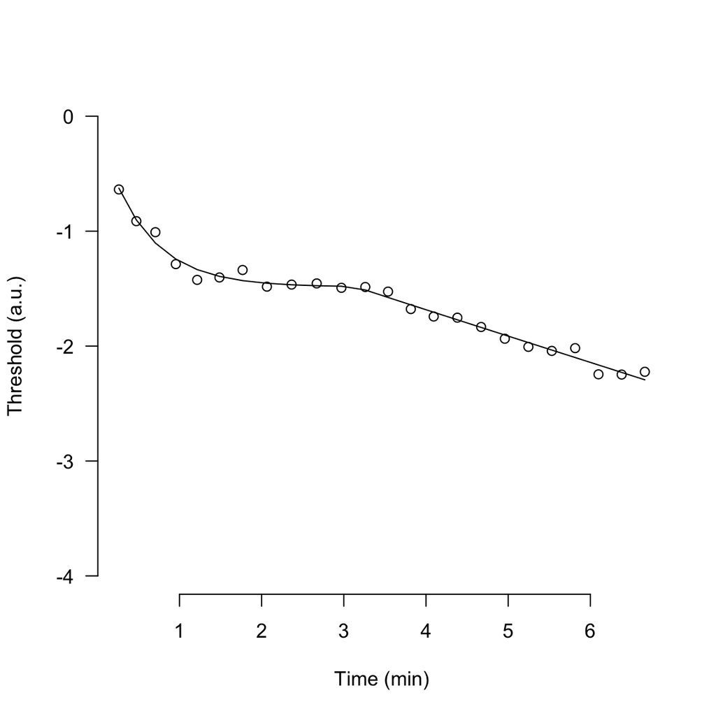

```r
# crosscheck SE for pk = 241
theta = c(-1.4854467,  1.3885495,  0.5477909, -0.2287327,  3.1289670 )
time <- x <- c(0.26296667, 0.4753    , 0.70723333, 0.9555    , 1.21553333,
       1.48633333, 1.7684    , 2.06418333, 2.36468333, 2.67003333,
       2.97075   , 3.26135   , 3.5383    , 3.81528333, 4.0935    ,
       4.38153333, 4.67076667, 4.95933333, 5.24596667, 5.53056667,
       5.81501667, 6.09876667, 6.38078333, 6.66281667)

thrs <- y <- c(-0.637, -0.913, -1.009, -1.287, -1.424, -1.403, -1.338, -1.483,
       -1.465, -1.455, -1.493, -1.486, -1.526, -1.678, -1.743, -1.753,
       -1.834, -1.936, -2.007, -2.042, -2.018, -2.246, -2.248, -2.224)
        P5c <- function(P,x){
          P[1] + P[2] * exp(-x/P[3]) + P[4] * (x - P[5])/(1 + exp(-2 *
+     20 * (x - P[5])))
        }
      par(las = 1, bty ='n')
       plot(time, thrs, ylim =c(-4,0), xlab ="Time (min)", ylab ="Threshold (a.u.)")
       lines(time,P5c(theta,x) )
```

the gradient can be found programmatically

```r
Gfn <- deriv(y~(ct + cc * exp(-x/tau) + S2 * (x - alpha)/(1 + exp(-2 *
+     20 * (x - alpha))) ), c("ct", "cc", "tau", "S2", "alpha"), function(ct,cc,tau,S2,alpha, x){})

G <- attr(Gfn(theta[1],theta[2],theta[3],theta[4],theta[5], x),"gradient")

sigma2 = (sum((y - P5c(theta,x))**2)/(length(time)-5))
SEs <- sqrt(sigma2 * diag(solve(t(G)%*%G)))
round(SEs,4)
```

```
##     ct     cc    tau     S2  alpha
## 0.0314 0.1371 0.0839 0.0142 0.1843
```

using inbuilt functions

```r
nlm1 <- nls(y~(ct + cc * exp(-x/tau) + S2 * (x - alpha)/(1 + exp(-2 *
+     20 * (x - alpha)))), start=c(ct = -1.5, cc = 1.3, tau = 0.6, S2 = -0.1, alpha = 3))
summary(nlm1)
```

```
##
## Formula: y ~ (ct + cc * exp(-x/tau) + S2 * (x - alpha)/(1 + exp(-2 * +20 *
##     (x - alpha))))
##
## Parameters:
##       Estimate Std. Error t value Pr(>|t|)
## ct    -1.48545    0.03144 -47.248  < 2e-16 ***
## cc     1.38855    0.13715  10.124 4.31e-09 ***
## tau    0.54779    0.08391   6.528 2.98e-06 ***
## S2    -0.22873    0.01418 -16.131 1.52e-12 ***
## alpha  3.12897    0.18434  16.974 6.14e-13 ***
## ---
## Signif. codes:  0 '***' 0.001 '**' 0.01 '*' 0.05 '.' 0.1 ' ' 1
##
## Residual standard error: 0.0546 on 19 degrees of freedom
##
## Number of iterations to convergence: 5
## Achieved convergence tolerance: 9.588e-07
```